# **Funciones**

- Mostrar todo el código
- Ocultar todo el código
- Ver el código fuente

Fecha de publicación

# Objetivo del manual

- Identificar los elementos básicos que componen una función
- Comprender las características de los principales tipos de argumentos en las funciones
- Ser capaz de construir funciones propias

# 1 Funciones en R

- Todo lo que sucede en `R` es una llamada de una función (i.e. las manipulaciones y cálculos de objetos en `R` se realizan a través de una función)
- Una función es una subrutina que tiene como objetivo realizar una tarea específica
- Permite a los usuarios juntar bloques de código que se usan con frecuencia y, por lo tanto, resulta conveniente encapsular en un objeto que se puede llamar fácilmente cuando sea necesario
- Las funciones cargadas desde los paquetes (incluido `R` básico) también se pueden modificar y sobrescribir

# 2 Estructura básica

Todas las funciones son creadas iguales … mediante la función `function()` y siguen la misma estructura:

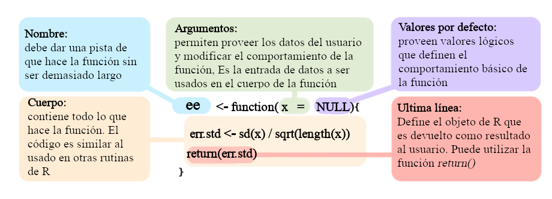

* Modificado de *Wickham et al. 2016*

Podemos observar la estructura de funciones ya cargadas en nuestro entorno de `R`. Para ver el código simplemente corra al nombre de la función en `R` (sin el paréntesis). Por ejemplo, el código de la función `sd()` se puede mostrar de la siguiente manera:

**Código**

```r
sd
```

```
function (x, na.rm = FALSE)
sqrt(var(if (is.vector(x) || is.factor(x)) x else as.double(x),
    na.rm = na.rm))
<bytecode: 0x60f4251d45a0>
<environment: namespace:stats>
```

En `Rstudio`, el código también se puede mostrar usando *F2* cuando el cursor está en el nombre de la función.

Además, podemos diseccionar las funciones en sus elementos básicos:

**Código**

```r
# cuerpo
body(sd)
```

```
sqrt(var(if (is.vector(x) || is.factor(x)) x else as.double(x),
    na.rm = na.rm))
```

**Código**

```r
# argumentos
formals(sd)
```

```
$x


$na.rm
[1] FALSE
```

**Código**

```r
# ambiente
environment(sd)
```

```
<environment: namespace:stats>
```

Algunas funciones `R` utilizan funciones primitivas (principalmente escritas en `C`). En estos casos, el código no se muestra:

**Código**

```r
sum
```

```
function (..., na.rm = FALSE)  .Primitive("sum")
```

**Código**

```r
body(sum)
```

[output not shown]

**Código**

```r
formals(sum)
```

[output not shown]

**Código**

```r
environment(sum)
```

[output not shown]

Las funciones son en sí mismas un tipo específico de objeto:

**Código**

```r
class(sd)
```

```
[1] "function"
```

Los operadores son funciones:

**Código**

```r
1 + 1
```

```
[1] 2
```

**Código**

```r
"+"(1, 1)
```

```
[1] 2
```

**Código**

```r
2 * 3
```

```
[1] 6
```

**Código**

```r
"*"(2, 3)
```

```
[1] 6
```

## 2.1 Nombre

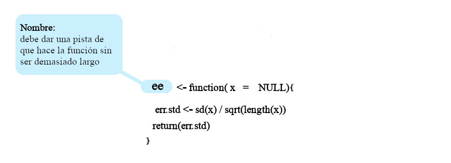

Los nombres de las funciones tienen pocas restricciones. Siguen las mismas reglas que otros objetos en `R`. Algunas recomendaciones/reglas:

- No utilice nombres de objetos comunes `R` (por ejemplo, *iris*, *x*) u objetos que ya están en el entorno
- No use nombres de funciones de uso frecuente (por ejemplo, `mean`)
- No puede comenzar con un número
- Debería sugerir lo que hace
- No debe ser muy largo

En caso de que tenga varias funciones con el mismo nombre, puede llamarlas individualmente utilizando el nombre del paquete (o *namespace*) seguido de `::`:

**Código**

```r
# crear funcion sd
sd <- function(x) x^10

# no calcula desv. st.
sd(1:5)
```

```
[1]       1    1024   59049 1048576 9765625
```

**Código**

```r
# sd
stats::sd(1:5)
```

```
[1] 1.5811
```

**Código**

```r
# remover nueva sd
rm(sd)

# usar de nuevo
sd(1:5)
```

```
[1] 1.5811
```

La sintaxis `namespace::function` también se puede usar para llamar a funciones desde paquetes que se han instalado pero que no están cargados en el entorno actual.

Las funciones pueden ser anónimas:

**Código**

```r
(function(x) x^10)(1:5)
```

```
[1]       1    1024   59049 1048576 9765625
```

Esto es más útil cuando se usan las funciones `Xapply`:

**Código**

```r
l <- list(1:5, 1:4, 1:3)

lapply(l, function(x) x^10)
```

```
[[1]]
[1]       1    1024   59049 1048576 9765625

[[2]]
[1]       1    1024   59049 1048576

[[3]]
[1]     1  1024 59049
```

## 2.2 Argumentos

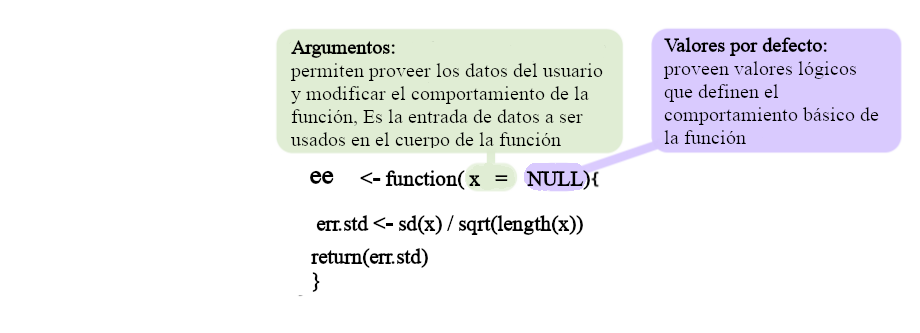

Permiten a los usuarios ingresar objetos en la función. Los argumentos pueden o no tener valores predeterminados. Cuando los argumentos tienen valores predeterminados, no es necesario proporcionarlos:

**Código**

```r
f1 <- function(x, y = 2) x + y

f1(1)
```

```
[1] 3
```

Por supuesto, se pueden modificar:

**Código**

```r
f1(3, 4)
```

```
[1] 7
```

Los argumentos sin valor predeterminado deben ser proporcionados:

**Código**

```r
f1()
```

```
Error in `f1()`:
! argument "x" is missing, with no default
```

Si todos los argumentos tienen un valor predeterminado, se puede invocar la función sin proporcionar ningún argumento:

**Código**

```r
f1 <- function(x = -2, y = 2) x + y

f1()
```

```
[1] 0
```

Ese es el caso de `dev.off()` y `Sys.time()`:

**Código**

```r
Sys.time()
```

```
[1] "2026-08-07 11:46:41.403 CST"
```

Los argumentos pueden especificarse implícitamente por posición o por nombres incompletos:

**Código**

```r
f2 <- function(a1, b1, b2) {
  list(a1 = a1, b1 = b1, b2 = b2)
}

# por posicion
str(f2(1, 2, 3))
```

```
List of 3
 $ a1: num 1
 $ b1: num 2
 $ b2: num 3
```

**Código**

```r
# por posicion y nombre
str(f2(a = 1, 2, 3))
```

```
List of 3
 $ a1: num 1
 $ b1: num 2
 $ b2: num 3
```

**Código**

```r
str(f2(1, a = 2, 3))
```

```
List of 3
 $ a1: num 2
 $ b1: num 1
 $ b2: num 3
```

**Código**

```r
str(f2(1, 2, a = 3))
```

```
List of 3
 $ a1: num 3
 $ b1: num 1
 $ b2: num 2
```

**Código**

```r
# por posicion y nombre parcial
str(f2(1, a = 2, b1 = 3))
```

```
List of 3
 $ a1: num 2
 $ b1: num 3
 $ b2: num 1
```

Sin embargo, esto no funciona si los nombres son ambiguos:

**Código**

```r
f2(b = 1, 2, a = 3)
```

```
Error in `f2()`:
! argument 1 matches multiple formal arguments
```

Es más seguro (y, por lo tanto, una mejor práctica) usar los nombres completos de los argumentos.

Las funciones también pueden tomar argumentos lógicos. Estos son útiles para modificar el comportamiento de la función para que coincida con diferentes escenarios. Por ejemplo, `mean()` permite a los usuarios ignorar los *NA*:

**Código**

```r
v1 <- c(1, 2, 3, NA)

# sin ignorar NAs
mean(v1, na.rm = FALSE)
```

```
[1] NA
```

**Código**

```r
# ignorando NAs
mean(v1, na.rm = TRUE)
```

```
[1] 2
```

## 2.3 Ejercicio 1

1.1 ¿Qué hace la función `cor.test()`?

1.2 Úsela con “Sepal.Length” y “Sepal.Width” de los datos de ejemplo *iris* (use `data(iris)`)

1.3 ¿Qué argumentos deben proporcionarse?

1.4 ¿Qué hace el argumento *alternative*? Use diferentes valores para este argumento y compare los resultados

1.5 ¿Cómo se puede calcular la correlación de Spearman?

1.6 ¿Qué tipo de objeto devuelve esta función?

1.7 ¿Cómo puede obtener el valor de **p** directamente del resultado de la función (sin guardar el resultado como un objeto)?

1.8 Escoga una función de R y lea su documentación con el fin de entender su uso, cada uno de sus argumentos (y que tipo de objetos requieren) y el resultado que produce (es probable que se le pida que explique esto al grupo)

## 2.4 Cuerpo

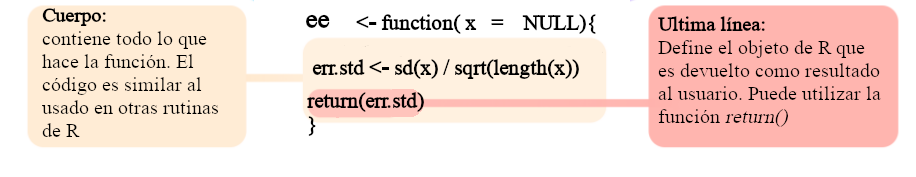

El cuerpo de una función puede contener:

- Comprobación de argumentos
- Manipulación de datos
- Definición de resultados

El cuerpo de la función puede tomar el mismo tipo de código utilizado en cualquier rutina de `R`. Sin embargo, los objetos creados no estarán disponibles en el entorno.

Cuando se realizan varios cálculos, debemos incluir una *declaración de retorno* (return statement), que define explícitamente la salida de la función. Esto se hace usando la función `return()`:

**Código**

```r
# sin "return statement"
f1 <- function(x, y) {
  z1 <- 2 * x + y
  z2 <- x + 2 * y
  z3 <- 2 * x + 2 * y
  z4 <- x / y
}

f1(5, 3)

f1_out <- f1(5, 3)

f1_out
```

```
[1] 1.6667
```

**Código**

```r
# con "return statement"
f2 <- function(x, y) {
  z1 <- 2 * x + y
  z2 <- x + 2 * y
  z3 <- 2 * x + 2 * y
  z4 <- x / y

  return(c(z1, z2, z3, z4))
}

f2(5, 3)
```

```
[1] 13.0000 11.0000 16.0000  1.6667
```

**Código**

```r
f2_out <- f2(5, 3)

f2_out
```

```
[1] 13.0000 11.0000 16.0000  1.6667
```

Por lo tanto, cuando no se proporciona una *declaración de retorno*, la función devolverá el último objeto que se creó en el cuerpo de la función:

**Código**

```r
# sin "return statement"
f3 <- function(x, y) {
  z1 <- 2 * x + y
  z2 <- x + 2 * y
  z3 <- 2 * x + 2 * y
  z4 <- x / y

  c(z1, z2, z3, z4)
}

f3(5, 3)
```

```
[1] 13.0000 11.0000 16.0000  1.6667
```

**Código**

```r
f3_out <- f3(5, 3)

f3_out
```

```
[1] 13.0000 11.0000 16.0000  1.6667
```

Es más seguro usar `return()`.

Cuando una función realiza varias tareas, podemos usar una lista para juntar los diferentes objetos. Esto es particularmente útil cuando se generan objetos de diferentes clases (por ejemplo, vectores y listas):

**Código**

```r
f4 <- function(x, y) {
  # 1 elemento
  z1 <- x + y

  # 2 elementos
  z2 <- c(x, y / 3)

  # vector logico
  z3 <- z2 < 10


  l <- list(z1, z2, z3)

  return(l)
}

f4(10, 5)
```

```
[[1]]
[1] 15

[[2]]
[1] 10.0000  1.6667

[[3]]
[1] FALSE  TRUE
```

Podemos acceder a elementos específicos de la salida de una función mediante indexación:

**Código**

```r
# elemento 1
f4(10, 5)[[1]]
```

```
[1] 15
```

**Código**

```r
# elemento 2
f4(10, 5)[[2]]
```

```
[1] 10.0000  1.6667
```

**Código**

```r
# elemento 3
f4(10, 5)[[3]]
```

```
[1] FALSE  TRUE
```

Por supuesto, también podemos guardar el resultado como un objeto y acceder a cada elemento mediante la indexación:

**Código**

```r
# elemento 1
out <- f4(10, 5)

# elemento 1
out[[1]]
```

```
[1] 15
```

**Código**

```r
# elemento 2
out[[2]]
```

```
[1] 10.0000  1.6667
```

## 2.5 Ejercicio 2

2.1 Cree una función llamada `promedio` que calcule el promedio de un vector numérico. Internamente solo puede utilizar las funciones `sum()` y `length()` (suma y división, no puede llamar la función `mean()`)

2.2 Cree una función que tome 2 argumentos numéricos (llámelos ‘x’ y ‘y’), eleve cada uno al cuadrado y luego los sume

2.3 Agregue valores predeterminados a cada argumento

2.4 Ejecute la función usando los valores predeterminados

2.5 Ejecute la función usando un valor predeterminado y uno proporcionado en la llamada

2.6 Ejecute la función proporcionando ambos valores en la llamada

# 3 Argumentos lógicos

Son argumentos que pueden tomar solo dos valores: `TRUE` o `FALSE`. Estos argumentos permiten modificar el comportamiento de la función de forma binaria: si es `TRUE` llevaría a cabo la tarea 1 y si es `FALSE` llevaría a cabo la tarea 2. Internamente (i.e. en el cuerpo de las función) estas funciones implican el uso del operador `if`, algunas veces incluyendo su contra-parte `else`. Estos operadores son parte fundamental de la programación y se usan para definir que acción ejecutar con base en una evaluación lógica:

**Código**

```r
# creemos el objeto a con valor 2
a <- 2

# elevemos a la 2 si a es mayor q 0
if (a > 0) {
  a^2
}
```

```
[1] 4
```

**Código**

```r
# elevemos a la 2 si a es mayor q 0 de lo contrario elevemoslo a la 100
if (a > 0) {
  a^2
} else {
  a^100
}
```

```
[1] 4
```

**Código**

```r
# con a negativo
a <- -3
if (a > 0) {
  a^2
} else {
  a^3
}
```

```
[1] -27
```

La parte dentro de los paréntesis justo después de `if` es la evaluación lógica.

Estos operadores son utilizados en el cuerpo de la función cuando esta lleva un argumento lógico. Por ejemplo, la siguiente función utiliza un argumento lógico para decidir si la operación algebraica a realizar es una suma o un promedio:

**Código**

```r
mean_sum <- function(x, y, prom = FALSE) {
  if (prom) {
    b <- mean(c(x, y))
  } else {
    b <- sum(c(x, y))
  }

  return(b)
}
```

Note que este tipo de argumentos deben tener un valor predeterminado. Podemos probar la función de la siguiente forma:

**Código**

```r
mean_sum(x = 2, y = 3)
```

```
[1] 5
```

## 3.1 Ejercicio 3

3.1 Cree una función que tome 3 argumentos numéricos, multiplíquelos y luego calcule el logaritmo natural del resultado (función `log()`)

3.2 Agregue valores predeterminados a cada argumento

3.3 Ejecute la función con uno de los argumentos con un número negativo. ¿Qué pasa? ¿Por qué?

3.4 Agregue un argumento lógico que permita a los usuarios (si lo desean) convertir los argumentos de entrada a su valor absoluto (usando la función `abs()`). Agregue las modificaciones necesarias para que la función haga los cálculos con y sin valores absolutos.

# 4 Ventajas de usar funciones

## 4.1 Código mas limpio

Los objetos creados dentro del cuerpo no están disponibles en el entorno actual:

**Código**

```r
# primero remover todo los objetos
rm(list = ls())

f5 <- function(x) {
  sqr <- x * x
  lg_sqr <- log(x)
  return(lg_sqr)
}

f5(7)
```

```
[1] 1.9459
```

**Código**

```r
exists("sqr")
```

```
[1] FALSE
```

**Código**

```r
exists("lg_sqr")
```

```
[1] FALSE
```

**Código**

```r
x <- 7
sqr <- x * x
lg_sqr <- log(x)


exists("sqr")
```

```
[1] TRUE
```

**Código**

```r
exists("lg_sqr")
```

```
[1] TRUE
```

## 4.2 Facil de correr y compartir

Se pueden invocar funciones desde archivos de `R` externos sin estar definidas en el código actual con la función `source()`. En este ejemplo creamos la función `fnctn_X`:

**Código**

```r
fnctn_X <- function(sq_mt, vctr) {
  # trasponer matriz y calcular est dev
  stp1 <- t(sq_mt)
  stp2 <- vctr * vctr

  # guardar en lista
  rslt <- list(stp1, stp2)
  return(rslt)
}

fnctn_X(sq_mt = cbind(c(1, 2), c(3, 4)), vctr = c(2, 3))
```

```
[[1]]
     [,1] [,2]
[1,]    1    2
[2,]    3    4

[[2]]
[1] 4 9
```

Guarde el código anterior en un archivo `R` llamado ‘function_X.R’. Ahora la función se puede cargar usando `source()`:

**Código**

```r
# removamosla del ambiente
rm(fnctn_X)

# cargar funcion
source("function_X.R")

# run it
fnctn_X(sq_mt = cbind(c(1, 2), c(3, 4)), vctr = c(2, 3))
```

```
[[1]]
     [,1] [,2]
[1,]    1    2
[2,]    3    4

[[2]]
[1] 4 9
```

Además, este código se puede compartir fácilmente. Se puede enviar por correo electrónico o publicar en línea. Incluso se puede cargar desde repositorios en línea:

**Código**

```r
# remover objetos
rm(list = ls())

# revisar si existe en ambiente actual
exists("fnctn_X")
```

```
[1] FALSE
```

**Código**

```r
# cargar desde el internet
source(
  paste0(
    "https://raw.githubusercontent.com/maRce10/",
    "r_avanzado_2023/master/data/function_x.r"
  )
)


# revisar si existe en ambiente actual
exists("fnctn_X")
```

```
[1] TRUE
```

## 4.3 Se aplica fácilmente a nuevos objetos

Esto ya debería ser obvio a este punto.

## 4.4 Otros consejos

- Construir funciones cortas:
  - Fácil de leer
  - Fácil de arreglar y actualizar
  - Si es demasiado largo, probablemente debería dividirse en varias funciones
  - Genera modularidad
- Añadir comentarios a todo el código
- Agregar descripciones a cada uno de los argumentos que toma
- Función de prueba con diferentes valores/escenarios

## 4.5 Ejercicio 4

4.1 Cree una funcion que calcule el promedio, la desviación estándar y el error estándar de un vector numérico. Estos valores deben ser devueltos como una lista con nombres.

4.2 Permita a los usuarios ignorar los `NAs` (similar al argumento `na.rm` en `mean()`, pista: añada un argumento lógico)

4.3 Haga que la función además produzca un histograma del vector numérico proporcionado por el usuario

4.4 Haga que la función escoja un color al azar para las barras del histograma cada vez que se corre (pista: `sample(vector.de.colores, 1)`)

4.5 Añada un argumento a la función que permita el usuario, si lo desea, calcular la sumatoria (`sum()`) junto con el resto de los descriptores estadísticos

4.6 Agregue el promedio y la desviación estándar al título del histograma (pista: use `paste()`)

4.7 Modifique la función para que también cree una linea vertical indicando el promedio del vector numérico proporcionado por el usuario

4.8 Modifique la función para que añada un polígono transparente sobre el área que cubre el promedio +/- la desviación estándar (puede usar la función `rect()`)

4.9 Modifique la función con un argumento lógico que permita al usuario controlar si se crea un gráfico o no

## 4.6 Lecturas adicionales

- [Introduction to R guide to writing functions with information for a total beginner](http://nicercode.github.io/intro/writing-functions.html)
- [Information on functions for intermediate and advanced users (Hadley Wickham)](https://twitter.com/hadleywickham).
- [The official R intro material on writing your own functions](http://cran.r-project.org/doc/manuals/R-intro.html#Writing-your-own-R-intro.html#Writing-your-own-functions) (ir a “Writing your own function”)

## 4.7 Referencias

- Wickham, Hadley, and Garrett Grolemund. 2016. *R for data science: import, tidy, transform, visualize, and model data*. [website](http://r4ds.had.co.nz)

Información de la sesión